# Aristarchus of Samos

- early understanding of Solar System and stars
- relative distances of Sun, Earth, and Moon
- relative sizes of Sun, Earth, and Moon
- size of Earth (Eratosthenes)

[Aristarchus of Samos](https://en.wikipedia.org/wiki/Aristarchus_of_Samos) (310-230 BCE) was probably the greatest astronomer of all time. Unfortunately, he was also ahead of his time—*way* ahead of his time. Our ability to measure the sizes of things and the state of mathematics at the time were insufficiently developed for the prescient natural philosophy of Aristarchus to have shaped history. Instead, we would spend the next 2000 or so years rediscovering what he was saying all along.

[figure not shown]

Historical diagram attributed to Aristarchus.

Fig1: A diagram taken from Aristarchus’ *On the Sizes and Distances (of the Sun and the Moon)*

Specifically, Aristarchus

- put the Sun at the center of the known universe,
- arranged the 5 known planets in the correct order,
- stated that the Earth revolves around the Sun in one year and rotates on its axis in one day,
- believed that the stars were like the Sun, only much farther away (and that that is why they look like they are fixed in the sky. *i.e.* not displaying noticeable parallax),
- pointed out that the Sun and the Moon have approximately the same apparent angular size,
- calculated the sizes of the Sun and the Moon relative to that of the Earth,
- calculated the distances to the Sun and the Moon in terms of the size of the Earth.

Let us emphasize that this was *almost two millennia* before the [**Copernican Revolution**](https://en.wikipedia.org/wiki/Copernican_Revolution). Some of what is on this list is nothing more than (correct) hypothesis, but some of it is hard science and math. Let’s see how he determined some of these important facts.

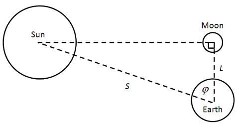

Quarter-moon Sun-Earth-Moon geometry.

In the diagram at right, Aristarchus considers the angle between the Sun and the Moon when the latter is in the **quarter-moon phase** in which it is (ironically) half-illuminated. Of course, the diagram is exaggerated greatly to illustrate the geometry: In reality the Sun-Earth distance $S$ is much larger than the Moon-Earth distance $L$ and the angle $\varphi$ is very close to $90{^\circ}$.

2. We will now use Aristarchus’ observation that the Sun and the Moon have approximately the same apparent angular size to show that the Sun is about 400 times larger than the Moon.
   1. Draw a diagram illustrating the relative position of the Sun, Moon, and Earth during a total **solar eclipse**. It should look like two overlapping isosceles triangles with the Earth at one vertex and the diameters of the Sun and Moon as their bases. Note that the triangles are similar in the mathematical sense, and use this to calculate the ratio of the diameters of the Sun and the Moon.
   2. Look up the radii of the Sun and the Moon and calculate a more accurate value for their relative size.
   3. What are major sources of uncertainty in your method that could account for this discrepancy?

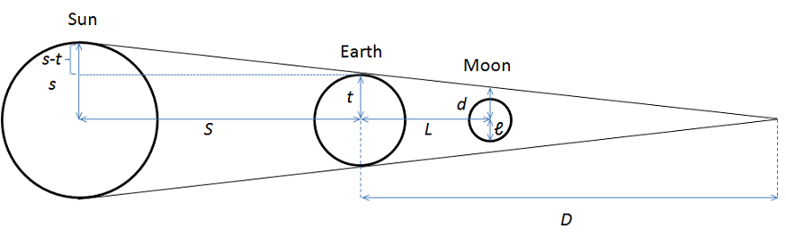

Lunar-eclipse geometry.

Next, consider the situation during a **lunar eclipse**, shown in the figure above. In this diagram, the Earth casts a shadow, or **umbra**, over the entire Moon because the radius $d$ of the Earth’s shadow at the distance of the Moon is larger than the radius $\ell$ of the Moon. The radii of the Sun and the Earth are denoted $s$ and $t$ (for *terra*), respectively.

$$\frac{s}{t} = \frac{s/\ell + 1}{d/\ell + 1}.
\tag{1}$$

The importance of the formula you just derived is that we know $s/\ell \approx 395$, so if we can determine the ratio $n = d/\ell$ of the Earth’s shadow relative to the radius of the Moon, we will know how the size of the Sun relative to that of Earth!

4. Below right is a photograph of a partial eclipse of the Moon by the shadow of the Earth with circles superimposed to match the curvature of the shadow and the cross-section of the Moon.
   1. Use a ruler to measure diameters and calculate the ratio $n = d/\ell$. (You might want to open the picture in another window and blow it up.)

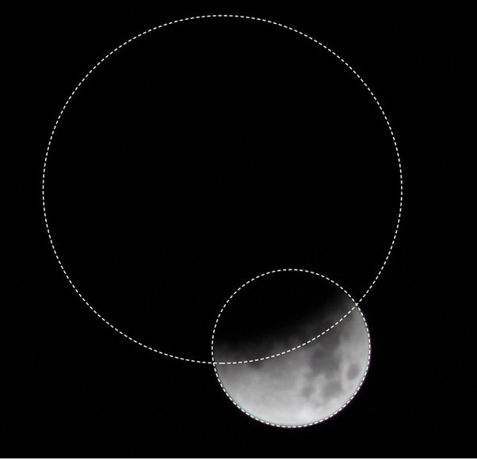

      Partial lunar eclipse with circular overlays.

   2. Determine the relative sizes Sun : Earth : Moon.

Congratulations! Following Aristarchus, you have managed to figure out the relative sizes and distances of the three main astronomical objects relevant to life on Earth!

Now, if only we could figure out the size of the Earth, we’d be all set. More than half a century after Aristarchus’ death, Eratosthenes figured out a method to determine the size of the Earth. A diagram representing his logic was taken from the text (p. 27) and is shown below.

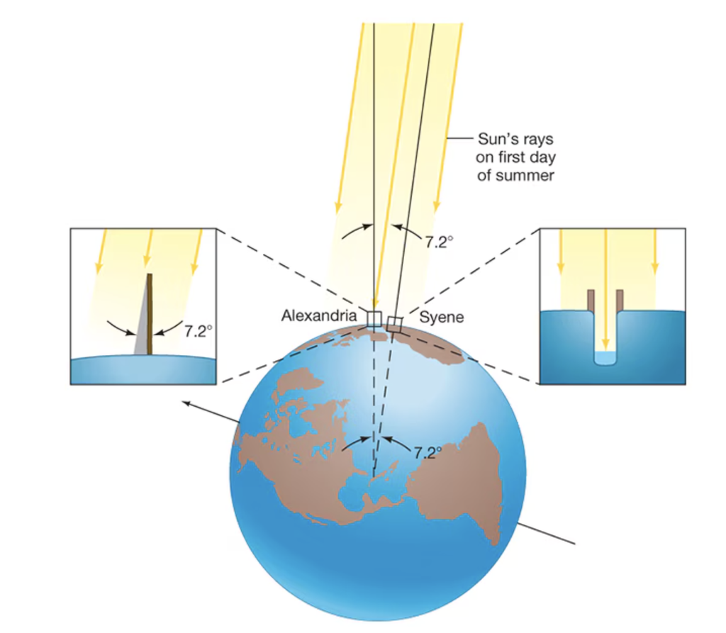

Eratosthenes geometry.

5. Write a detailed explanation of what is happening in this diagram. Describe how to use it to determine the radius of the Earth, and calculate the value using a distance of 800 km for the distance between Alexandria and Syene (Aswan). What does this give for the sizes of the Moon and Sun and the distances to them?

## Footnotes

[^1]: Actually, Aristarchus did not even have the benefit of trigonometric geometry. The first trigonometric tables were constructed half a century later by another astronomy great: [Hipparchus of Nicaea](https://en.wikipedia.org/wiki/Hipparchus) (190-120 BCE).